# Compare aggregated and non-aggregated reference: SCPCL000125

Stephanie J. Spielman

2025-07-09

This notebook does some preliminary comparisons of `SingleR` results obtained with the NBAtlas reference, where the reference was either aggregated before training or not. The goal is to determine whether there are substantial differences between aggregation versions. Note that the goal of this notebook is *not* specifically to validate annotations, but to compare whether the aggregated vs non-aggregated reference yield different or similar labels. There is, however, a brief comparison to consensus annotations.

## Setup

```r
options(readr.show_col_types = FALSE)
suppressPackageStartupMessages({
  library(ggplot2)
  library(patchwork)
  library(SingleCellExperiment)
})

theme_set(theme_bw())

# Define color ramp for shared use in the heatmaps
heatmap_col_fun <- circlize::colorRamp2(c(0, 1), colors = c("white", "darkslateblue"))
# Set heatmap padding option
ComplexHeatmap::ht_opt(TITLE_PADDING = grid::unit(0.6, "in"))
```

### Paths

```r
# The base path for the OpenScPCA repository, found by its (hidden) .git directory
repository_base <- rprojroot::find_root(rprojroot::is_git_root)

module_dir <- file.path(repository_base, "analyses", "cell-type-neuroblastoma-04")
results_dir <- file.path(module_dir, "results")
aggr_results_dir <- file.path(results_dir, "singler-test_aggregated")
non_aggr_results_dir <- file.path(results_dir, "singler-test_not-aggregated")
data_dir <- file.path(repository_base, "data", "current", "SCPCP000004")
```

```r
# broad consensus cell type groups
validation_url <- "https://raw.githubusercontent.com/AlexsLemonade/OpenScPCA-analysis/refs/heads/main/analyses/cell-type-consensus/references/consensus-validation-groups.tsv"

# umap colors
palette_url <- "https://raw.githubusercontent.com/AlexsLemonade/scpca-paper-figures/refs/heads/main/palettes/validation-group-palette.tsv"
```

```r
# SingleR results
aggr_singler_file <- file.path(
  aggr_results_dir,
  params$sample_id,
  glue::glue("{params$library_id}_singler-results.rds")
)

non_aggr_singler_file <- file.path(
  non_aggr_results_dir,
  params$sample_id,
  glue::glue("{params$library_id}_singler-results.rds")
)

# SCE file
sce_file <- file.path(
  data_dir,
  params$sample_id,
  glue::glue("{params$library_id}_processed.rds")
)
```

### Functions

```r
# Source Jaccard and heatmap utilities functions:
source(file.path(module_dir, "exploratory-notebooks", "jaccard-utils.R"))

# This function calculates and returns a confusion matrix
#
# df: data frame with columns of interest
# annotation_col1: first column to compare; arg should be a string
# annotation_col2: second column to compare; arg should be a string
calculate_confusion <- function(
    df,
    annotation_col1,
    annotation_col2) {
  # determine all possible annotation values for caret
  all_levels <- union(
    unique(df[[annotation_col1]]),
    unique(df[[annotation_col2]])
  )

  caret::confusionMatrix(
    factor(df[[annotation_col1]], levels = all_levels),
    factor(df[[annotation_col2]], levels = all_levels),
    mode = "sens_spec"
  )
}

# This function calculates and plots delta median for two groups of barcodes: those in agree and those not
# This code is based on this scpca-nf code:
# https://github.com/AlexsLemonade/scpca-nf/blob/4bb82aa635b572a62f2028dbec587fcfd2155e26/templates/qc_report/celltypes_supplemental_report.rmd#L626
#
# df: SingleR data frame with `scores.` columns
# agree_barcodes: Vector of barcodes that have agreeing labels between aggregated and not
# plot_title: Title for plot
plot_delta_median <- function(df, agree_barcodes, plot_title) {
  # extract scores into matrix
  scores_mat <- df |>
    dplyr::select(starts_with("scores.")) |>
    as.matrix()
  rownames(scores_mat) <- df$barcodes

  # Create data frame for plotting with delta median and the full *non-pruned* cell labels
  delta_median_df <- tibble::tibble(
    delta_median = rowMaxs(scores_mat) - rowMedians(scores_mat),
    # Need to grab the non-pruned label for this plot
    full_labels = aggr$labels,
    # if pruned.labels are NA ==> low confidence
    # so, negate for this variable:
    confident = !is.na(df$pruned.labels)
  ) |>
    dplyr::mutate(
      confident = ifelse(confident, "High-quality", "Low-quality"),
      barcodes = df$barcodes,
      annotations_agree = barcodes %in% agree_barcodes
    )

  ggplot(delta_median_df) +
    aes(x = annotations_agree, y = delta_median, color = confident) +
    # don't jitter the height
    geom_jitter(height = 0, alpha = 0.7) +
    theme(legend.position = "bottom") +
    ggtitle(plot_title)
}
```

### Prepare input data

Read SCE object so we can get consensus cell types:

```r
sce_df <- readRDS(sce_file) |>
  scuttle::makePerCellDF() |>
  dplyr::select(
    barcodes,
    consensus_annotation = consensus_celltype_annotation,
    UMAP1 = UMAP.1,
    UMAP2 = UMAP.2
  )
```

Read cell type data frames:

```r
validation_df <- readr::read_tsv(validation_url) |>
  dplyr::select(consensus_annotation, validation_group_annotation)

palette_df <- readr::read_tsv(palette_url) # umap plotting later

aggr <- readr::read_rds(aggr_singler_file) |>
  as.data.frame() |>
  tibble::rownames_to_column("barcodes")

non_aggr <- readr::read_rds(non_aggr_singler_file) |>
  as.data.frame() |>
  tibble::rownames_to_column("barcodes")
```

Join and prepare data for use:

```r
singler_df <- data.frame(
  barcodes = aggr$barcodes,
  "aggregated" = aggr$pruned.labels,
  "not_aggregated" = non_aggr$pruned.labels
)

celltype_df <- sce_df |>
  dplyr::left_join(singler_df, by = "barcodes") |>
  dplyr::left_join(validation_df, by = "consensus_annotation") |>
  # set validation NA -> unknown
  dplyr::mutate(
    validation_group_annotation =
      ifelse(is.na(validation_group_annotation), "unknown", validation_group_annotation)
  )
```

## Aggregated vs. non-aggregated

First a quick and dirty query: What percent of annotations made with either the aggregated and non-aggregated reference versions agree?

```r
sum(singler_df$aggregated == singler_df$not_aggregated, na.rm = T) / nrow(singler_df)
```

```
[1] 0.9448508
```

Where specifically are their disagreements? This table displays the number of cells that have the given cell label disagreements:

```r
singler_df |>
  dplyr::filter(aggregated != not_aggregated) |>
  dplyr::count(aggregated, not_aggregated) |>
  dplyr::arrange(desc(n))
```

| aggregated | not_aggregated | n |
| --- | --- | --- |
| Schwann | Fibroblast | 12 |
| Endothelial | Fibroblast | 5 |
| Endothelial | Schwann | 1 |
| NK cell | T cell | 1 |
| Neuroendocrine | Stromal other | 1 |
| Schwann | Stromal other | 1 |
| T cell | NK cell | 1 |

### Delta median scores

We’ll plot the `delta_median` scores for each `SingleR` inference (aggregated and non-aggregated) for cells where annotations agree vs. differ. We would like to see that scores will be *lower* for the cells where inferences between reference versions disagree. Cells will also be colored by their reliability as determined by `SingleR`.

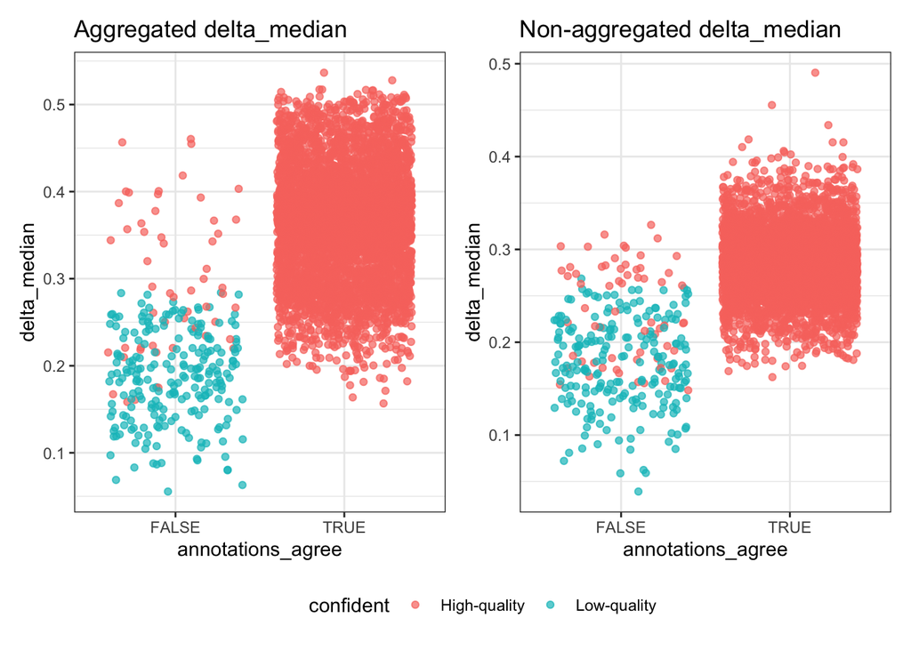

```r
agree_barcodes <- singler_df |>
  dplyr::filter(aggregated == not_aggregated) |>
  dplyr::pull(barcodes)

plot_delta_median(aggr, agree_barcodes, plot_title = "Aggregated delta_median") +
  plot_delta_median(non_aggr, agree_barcodes, plot_title = "Non-aggregated delta_median") +
  plot_layout(guides = "collect") & theme(legend.position = "bottom")
```

### Confusion matrix metrics

Here are metrics from a confusion matrix comparing these annotations:

```r
calculate_confusion(
  celltype_df,
  "aggregated",
  "not_aggregated"
)
```

```
Confusion Matrix and Statistics

                Reference
Prediction       Endothelial Schwann Neuroendocrine Myeloid Plasma Fibroblast
  Endothelial           1216       1              0       0      0          5
  Schwann                  0    1799              0       0      0         12
  Neuroendocrine           0       0             38       0      0          0
  Myeloid                  0       0              0     554      0          0
  Plasma                   0       0              0       0      8          0
  Fibroblast               0       0              0       0      0        637
  T cell                   0       0              0       0      0          0
  RBCs                     0       0              0       0      0          0
  NK cell                  0       0              0       0      0          0
  pDC                      0       0              0       0      0          0
  B cell                   0       0              0       0      0          0
  Stromal other            0       0              0       0      0          0
                Reference
Prediction       T cell RBCs NK cell  pDC B cell Stromal other
  Endothelial         0    0       0    0      0             0
  Schwann             0    0       0    0      0             1
  Neuroendocrine      0    0       0    0      0             1
  Myeloid             0    0       0    0      0             0
  Plasma              0    0       0    0      0             0
  Fibroblast          0    0       0    0      0             0
  T cell            483    0       1    0      0             0
  RBCs                0    4       0    0      0             0
  NK cell             1    0      27    0      0             0
  pDC                 0    0       0   13      0             0
  B cell              0    0       0    0      1             0
  Stromal other       0    0       0    0      0             0

Overall Statistics

               Accuracy : 0.9954
                 95% CI : (0.9931, 0.9971)
    No Information Rate : 0.3748
    P-Value [Acc > NIR] : < 2.2e-16

                  Kappa : 0.9939

```

[output cut: 25 more lines]

```
Pos Pred Value              0.9979    1.000000       0.964286   1.000000
Neg Pred Value              0.9998    1.000000       0.999791   1.000000
Prevalence                  0.1008    0.000833       0.005831   0.002707
Detection Rate              0.1006    0.000833       0.005623   0.002707
Detection Prevalence        0.1008    0.000833       0.005831   0.002707
Balanced Accuracy           0.9989    1.000000       0.982038   1.000000
                     Class: B cell Class: Stromal other
Sensitivity              1.0000000            0.0000000
Specificity              1.0000000            1.0000000
Pos Pred Value           1.0000000                  NaN
Neg Pred Value           1.0000000            0.9995835
Prevalence               0.0002082            0.0004165
Detection Rate           0.0002082            0.0000000
Detection Prevalence     0.0002082            0.0000000
Balanced Accuracy        1.0000000            0.5000000
```

### Heatmap: Aggregated vs. non-aggregated

This heatmap compares annotations between aggregated and non-aggregated directly:

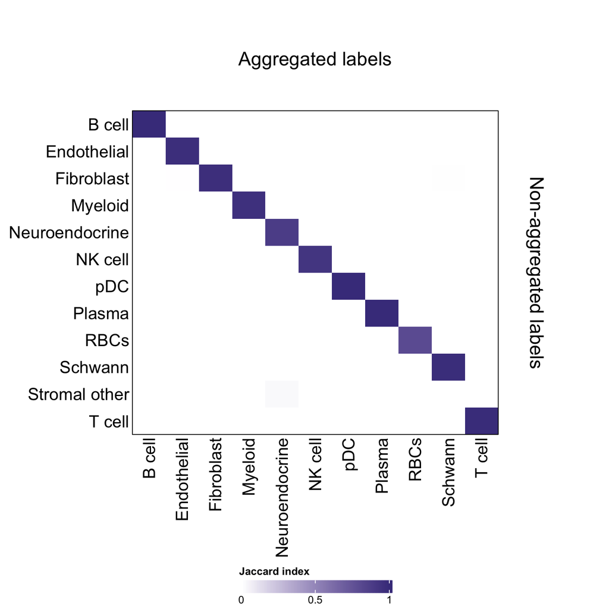

```r
make_jaccard_heatmap(
  celltype_df,
  "aggregated",
  "not_aggregated",
  "Aggregated labels",
  "Non-aggregated labels"
)
```

## Comparison with consensus cell type annotations

In this section, we compare aggregated & non-aggregated annotations to the consensus cell type labels. In these comparisons, we consider the broader validation groupings for consensus cell types in order to keep plots manageable and more easily interpreted.

### Heatmap: Aggregated vs. consensus annotations

This heatmap compares annotations between `SingleR` inference using the aggregated reference and consensus cell types.

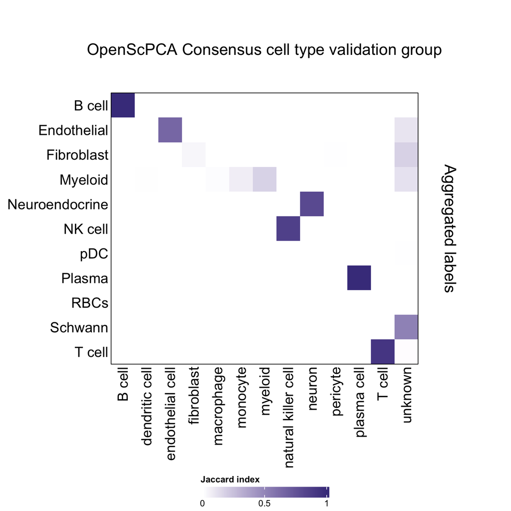

```r
make_jaccard_heatmap(
  celltype_df,
  "validation_group_annotation",
  "aggregated",
  "OpenScPCA Consensus cell type validation group",
  "Aggregated labels"
)
```

### Heatmap: Non-aggregated vs. consensus annotations

This heatmap compares annotations between `SingleR` inference using the non-aggregated reference and consensus cell types.

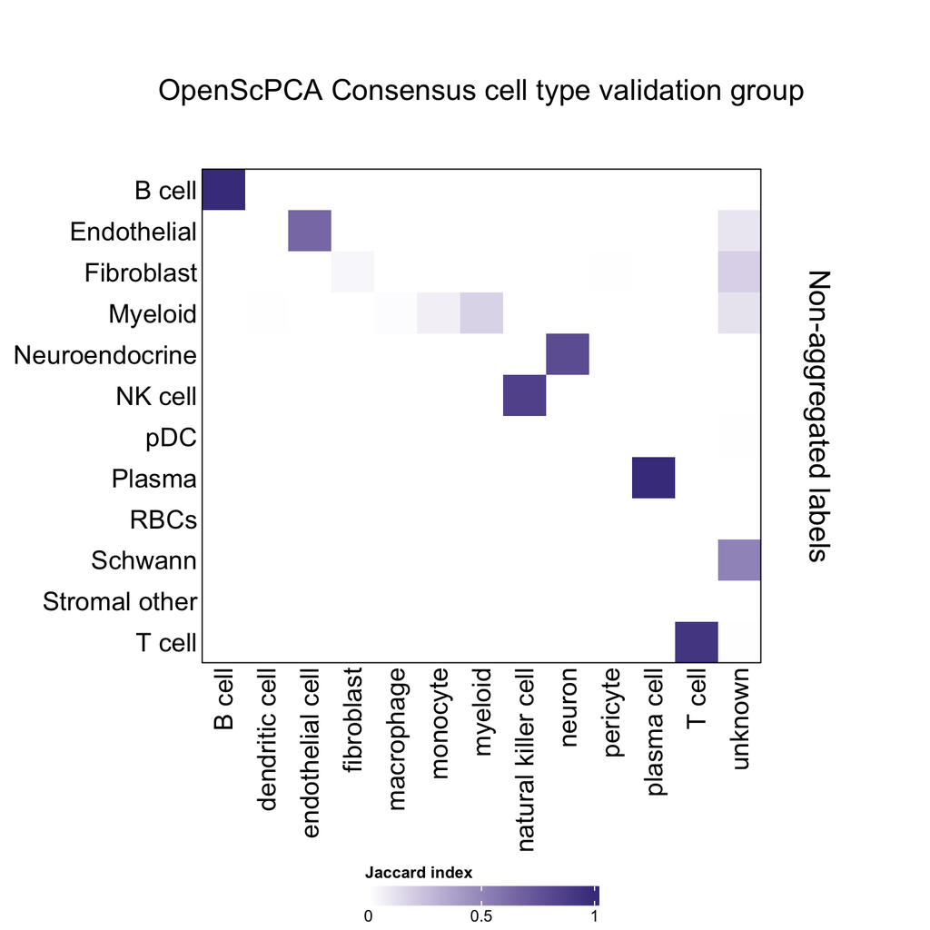

```r
make_jaccard_heatmap(
  celltype_df,
  "validation_group_annotation",
  "not_aggregated",
  "OpenScPCA Consensus cell type validation group",
  "Non-aggregated labels"
)
```

## UMAPs

Below, we show the UMAPs colored by cell types for each of aggregated, non-aggregated, and consensus (again, using the validation groupings for plot visibility).

Before plotting cell type labels were harmonized to the extent possible to that `NBAtlas` labels matched the corresponding consensus cell type labels (e.g., `Fibroblast` -> `fibroblast` or `Endothelial` -> `endothelial cell`). Cell types that were not literally just spelling variants were left alone; note that `stromal` cell types between references were also not harmonized since this group doesn’t always have a clear definition.

The UMAP therefore has one overall legend for all possible cell types, so colors are directly comparable across panels. The specific cell types that are part of either refernce are printed below.

```r
# Recode NBAtlas cell types where possible so they match with colors
celltype_recoded_df <- celltype_df |>
  dplyr::select(-consensus_annotation) |>
  # pivot longer for wrangling first
  tidyr::pivot_longer(
    c(validation_group_annotation, aggregated, not_aggregated),
    names_to = "annotation_type",
    values_to = "label"
  ) |>
  dplyr::mutate(
    label_recoded = dplyr::case_when(
      # nbatlas ~ consensus
      label %in% c("Myeloid", "Fibroblast") ~ stringr::str_to_lower(label),
      label == "Endothelial" ~ "endothelial cell",
      label == "Plasma" ~ "plasma cell",
      label == "NK cell" ~ "natural killer cell",
      is.na(label) ~ "unknown",
      .default = label
    )
  )

# For a set of consensus cell types that don't appear in samples this notebook explores
#  we'll grab their colors to use as NBAtlas labels.
# We'll do this by recoding cell consensus types associated with a set of colors to use, and
#  finally discard cell type labels which won't appear in the plot.
palette_df <- palette_df |>
  dplyr::mutate(
    # colors associated with these original validation groups will be now used to
    # color the given the NBAtlas cell types
    label_recoded = dplyr::case_when(
      validation_group_annotation == "hematopoietic precursor cell" ~ "Neuroendocrine",
      validation_group_annotation == "muscle cell" ~ "RBCs",
      validation_group_annotation == "adipocyte" ~ "Schwann",
      validation_group_annotation == "pericyte" ~ "pDC",
      validation_group_annotation == "innate lymphoid cell" ~ "Stromal other",
      .default = validation_group_annotation
    )
  ) |>
  # get rid of any cell types that won't appear in the plot so palette_df just contains
  # colors & cell types of interest
  dplyr::filter(label_recoded %in% unique(celltype_recoded_df$label_recoded))

# Define palette as a vector from all remaining colors/labels
pal <- palette_df$color
names(pal) <- palette_df$label_recoded
```

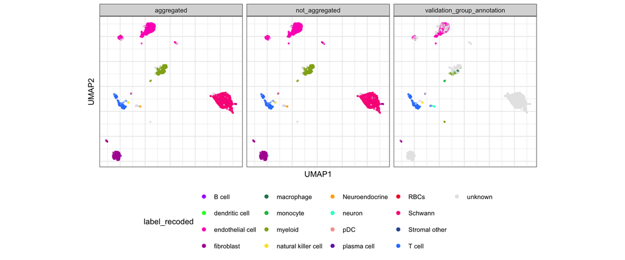

```r
ggplot(celltype_recoded_df) +
  aes(x = UMAP1, y = UMAP2, color = label_recoded) +
  geom_point(alpha = 0.6, size = 0.5) +
  scale_color_manual(values = pal) +
  facet_wrap(vars(annotation_type)) +
  coord_equal() +
  theme(
    axis.ticks = element_blank(),
    axis.text = element_blank(),
    legend.position = "bottom"
  ) +
  guides(color = guide_legend(override.aes = list(size = 2, alpha = 1)))
```

Cell types that are part of `NBAtlas` include:

```r
celltype_recoded_df |>
  dplyr::filter(annotation_type != "validation_group_annotation") |>
  dplyr::pull(label_recoded) |>
  unique()
```

```
 [1] "endothelial cell"    "Schwann"             "Neuroendocrine"
 [4] "myeloid"             "plasma cell"         "unknown"
 [7] "fibroblast"          "T cell"              "RBCs"
[10] "natural killer cell" "pDC"                 "B cell"
[13] "Stromal other"
```

```
endothelial cell
Schwann
Neuroendocrine
myeloid
plasma cell
unknown
fibroblast
T cell
RBCs
natural killer cell
pDC
B cell
Stromal other
```

Cell types that are part of consensus labels include:

```r
celltype_recoded_df |>
  dplyr::filter(annotation_type == "validation_group_annotation") |>
  dplyr::pull(label_recoded) |>
  unique()
```

```
 [1] "unknown"             "endothelial cell"    "neuron"
 [4] "plasma cell"         "myeloid"             "T cell"
 [7] "fibroblast"          "dendritic cell"      "monocyte"
[10] "macrophage"          "natural killer cell" "pericyte"
[13] "B cell"
```

```
unknown
endothelial cell
neuron
plasma cell
myeloid
T cell
fibroblast
dendritic cell
monocyte
macrophage
natural killer cell
pericyte
B cell
```